# Final Project: Mouse Microbiomes

### AC209b | Spring 2021

**Group Members**: Victor Avram, Blake Bullwinkel, Teresa Datta, and Kristen Grabarz

**Video Link**: https://harvard.zoom.us/rec/share/fcqGa-4MSyx5K5Q_A_0jOQSy8LKkaBbVE02nMtuX9dL6Or3CwzO8cT2MR8zQ164R.IXfwh9d0K9pP9Y7-?startTime=1620673889000

```python
# Import relevant packages
import pandas as pd
import numpy as np
import matplotlib.pyplot as plt
from sklearn.decomposition import PCA
from sklearn.metrics import f1_score, confusion_matrix
from sklearn.model_selection import train_test_split
from sklearn.linear_model import LinearRegression
from sklearn.preprocessing import MinMaxScaler
import tensorflow as tf
from tensorflow.keras import backend
from tensorflow.keras import Model, Sequential
from tensorflow.keras.layers import Input, SimpleRNN, Embedding, Dense, \
                            TimeDistributed, GRU, Dropout, Bidirectional, \
                            Conv1D, BatchNormalization, LSTM
from tensorflow.keras.models import model_from_json
from tensorflow.keras.preprocessing.sequence import pad_sequences
from tensorflow.keras.utils import to_categorical
from tensorflow import keras
from tensorflow.keras import layers
from sklearn.metrics import mean_squared_error, r2_score
import pandasql as ps
import random
import editdistance
import seaborn as sns
```

## 1. Background, Context & Motivation

### 1.1 Background & Motivation

The microbiome, composed of trillions of cells, is an important factor for human health. Microbial communities are critical in influencing function of the digestive tract, brain, skin, immunity, and reproductive systems, and disruptions to the balance of one’s microbiome can give rise to negative health effects such as infections or neurological diseases. In light of this, and given the growing interest in microbiome-based therapies such as bacteriotherapies, a wide body of previous research has illuminated important insights. In recent decades, the human microbiome has garnered broad attention from researchers — for example, the Human Microbiome Project) represents an initiative to understand how microbial components of human genetics and metabolic systems contribute to physiology and disease.

### 1.2 Previous Literature

Previous research has illuminated a great deal about the benefits and dynamics of the microbiome. Importantly, microbiomes are also inherently dynamic, and can change over time due to such factors as maturation, diet changes, illness or medical interventions. A body of research, leveraging technology and computational methods, has focused on elucidating the dynamics of microbiota and exploring methods of modeling it mathematically in response to natural temporal variability and [perturbations like antibiotics or dietary changes](https://www.sciencedirect.com/science/article/pii/S0014579314001574). Novel methods of inferring dynamical systems models from microbiome time series data have emerged, such as [Microbial Dynamical Systems Inference Engine (MDSINE)](https://link.springer.com/article/10.1186/s13059-016-0980-6), which has been shown to perform accurate forecasting of microbial dynamics, prediction of stable sub-communities inhibiting pathogen growth, and identification of bacteria that is vital to community integrity in response to perturbations. Further, challenges of microbiome data include high dimensionality, temporal sparsity, and non-uniformly sampled data, and methods such as a Bayesian nonparametric model based on interaction modules (ICML) have been shown to be [effective](http://proceedings.mlr.press/v80/gibson18a.html) in gaining biological insights into microbial therapy design.

Because of the link between microbial communities and health, an area of work has evolved to develop microbiome-based therapies such as faecal microbiota transplantation, in which healthy bacteria is transferred through stool from a donor into the intestine of a patient to restore the microbial balance and help fight infection. Research has indicated that despite nuances in microbial communities from one subject to another, gut and mouth microbiomes display universal dynamics, which can be useful in designing [generalized microbiome therapy methods](https://www.nature.com/articles/nature18301). In this way, mice have been used to address how bacteriophages impact bacterial communities in the gut. [Hsu et al.](https://www.sciencedirect.com/science/article/pii/S193131281930246X) utilize this approach to specifically show how phages not only can coexist overtime with specific bacteria, but can also specifically induce cascading effects on not directly targeted microorganisms and impact the gut metabolome.

### 1.3 Research Questions

Motivated by this previous work, along with deep learning methods explored throughout the class, our project aims to leverage deep learning methods to perform quantitiative regression on time series qPCR measurement data, as well as classification of donor health status based on microbiome profile.

## 2. Description of Data

For this project, we work with data from a mouse study to better understand the workings of the microbiome. Over the span of 70 days, various perturbations were performed on mice with microbiomes received from either healthy or infected sample donors. Perturbations included a high fat diet, Vancomycin, and Gentamicin, and were applied to mice at the same point. in time. An overview of the study design is shown in the following figure

[figure not shown]

We utilized five TSV files that were provided by the teaching team:

- **asv_and_taxonomy.tsv** : information on taxonomy of each ASV bacteria
- **counts.tsv**: Relative abundance of different taxa of bacteria in each sample
- **metadata.tsv**: Connects each sampleID to mouse identifier and date of sample
- **perturbations.tsv**: When each mouse subject underwent each perturbation
- **qpcr.tsv**: Total bacterial concentrations for each sample

```python
# Read in relevant datasets
asv_and_taxonomy = pd.read_csv('data/asv_and_taxonomy.tsv', sep='\t')
metadata = pd.read_csv('data/metadata.tsv', sep='\t')
perturbations = pd.read_csv('data/perturbations.tsv', sep='\t')
qpcr = pd.read_csv('data/qpcr.tsv', sep='\t')
counts = pd.read_csv('data/counts.tsv', sep='\t')
metadata = pd.read_csv('data/metadata.tsv', sep='\t')
```

### 2.1 Data Cleaning & Preparation

Along with the information provided by the guest lecturers, we performed initial explorations of the data through visualizations which we will discuss in the next section. Missing data was not found to be a concern. The first step in our data cleaning process was to transform the ASV counts to relative abundances for interpretation and use in our future models. Recall that counts are not absolute, but are rather relative to the read depth. The total read depth for each sample can be computed by summing the counts, and then relative abundance can be derived by dividing counts by the read depth.

```python
# Convert the first column specifying the species to the index
counts = counts.set_index('Unnamed: 0', drop=True)

# Perform sequencing depth normalization
read_depth=counts.sum()
counts = counts.div(read_depth, axis=1)
```

Next, we performed additional cleaning of the ASV count data by limiting it to only those species that appear at non-negligible frequencies. To accomplish this, we filtered out any species in the ASV counts dataset having a maximum relative abundance of less than 0.00005. In doing so, we found that nearly 40% of bacteria taxa (587 out of 1473 rows) had max relative abundance of less than 0.00005 and were removed.

```python
def remove_nonspecies(c):
    # removes all bacteria taxa species (rows) in counts df which have a max relative abundance of less than 0.00005
    c['max_count'] = c.max(axis = 1)
    c = c[c['max_count']> 0.00005]
    c.drop(columns = ['max_count'])
    return c

counts_cleaned = remove_nonspecies(counts)

num_removed = counts.shape[0]- counts_cleaned.shape[0]
print(num_removed,"out of", counts.shape[0], "rows (bacteria taxa) had max relative abundance of less than 0.00005 and were removed")
```

```
587 out of 1473 rows (bacteria taxa) had max relative abundance of less than 0.00005 and were removed
```

## 3. Select EDA

Before building models, we performed exploratory data analysis to build contextual knowledge of the data's structure and patterns, as well as provide footing for our subsequnt modeling objectives.

```python
# Determine the number of bateria species and the number of samples
num_species,num_samples = counts.shape
print(f"There are {num_species} unique species.")
print(f"There are {num_samples} samples.")

# Determine the number of unique classes and the number of unique orders
num_classes,num_orders = asv_and_taxonomy['Class'].nunique(),asv_and_taxonomy['Order'].nunique()
print(f"There are {num_classes} unique classes.")
print(f"There are {num_orders} unique orders.")
```

```
There are 1473 unique species.
There are 687 samples.
There are 24 unique classes.
There are 43 unique orders.
```

### 3.1 qPCR Over Time for Healthy & UC Donor Mice

First, we explore the qPCR measurements for a healthy and UC donor mouse to assess the trends over time and visualize responses to perturbations.

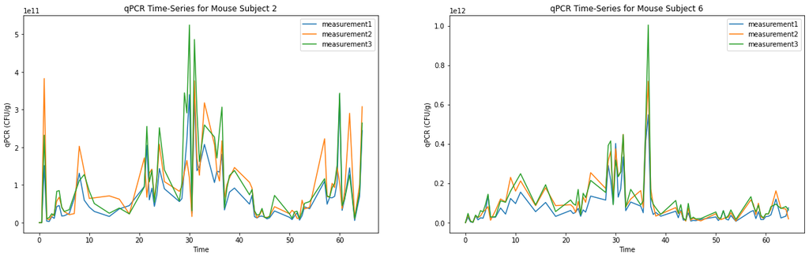

```python
# Plot qPCR for Healthy v. UC Donor Mouse

# Make a copy of qpcr for plotting
qpcr_copy = qpcr.copy()

# Add the 'subject' and 'time' in metadata to qpcr
qpcr_copy = qpcr_copy.merge(metadata, left_on='sampleID', right_on='sampleID')

# Filter the data for mouse 2 and mouse 6
mouse2_data = qpcr_copy[qpcr_copy['subject'] == 2]
mouse6_data = qpcr_copy[qpcr_copy['subject'] == 6]

# Define variables for plotting
measurements = ['measurement1', 'measurement2', 'measurement3']
mice_nums = [2, 6]
dfs = [mouse2_data, mouse6_data]

# Plot the time series of measurement1, measurement2, measurement3 for mouse 2 and mouse 6
fig, axs = plt.subplots(1, 2, figsize=(21, 6))
for i in range(2):
    for m in measurements:
        sorted_idx = np.argsort(dfs[i]['time'].to_numpy())
        sorted_measurements = dfs[i][m].to_numpy()[sorted_idx]
        axs[i].plot(sorted(dfs[i]['time']), sorted_measurements, label=m)
    axs[i].set_xlabel('Time')
    axs[i].set_ylabel('qPCR (CFU/g)')
    axs[i].set_title('qPCR Time-Series for Mouse Subject '+str(mice_nums[i]))
    axs[i].legend()
plt.show()
```

### 3.2 Relative Abundance of Taxa over Time by Healthy vs. UC Donor Mice

As part of our EDA, we explored how the relative abundance of bacterial species changes over time among the mice. Specifically, we are interested in what happens during and after a given perturbation (i.e. introduction of a broad-spectrum antibiotic). The figures below show the changes over time in the relative abundance of different phyla for a mouse with a healthy donor and one with a UC donor. We also explored breakdowns by other taxonomic groupings, such as class or family, but excluded these from our final code report for the sake of brevity. A breakdown by kingdom indicated thta dominant kingdom present in both mice is Bacteria. There are no obvious changes in the relative abundance of either kingdom (there are effectively no Archaea relative to Bacteria).

Vancomycin was introduced at 35.5 days and stopped at 42.5 days. Gentamycin was introduced at 50.5 days and stopped at 57.5 days. Interestingly, we see a similar relative abundance pattern between the two mice. However, exposure to Vancomycin produces a noticeable increase in the abundance of proteobacteria along with a reduction in the abundance of Actinobacteria in mouse 2 (healthy donor). This signature is not found in mouse 6 (unhealthy donor).

Additionally, these results indicate that at a given point in time, the majority of each mouse's microbiome can be broken down into four to five groups. Also, the breakdown of relative abundances does not change materially with more granular taxonomic breakdowns (e.g. a similar number of groups make up most of the relative abundance at the Phylum level as at the Class or Order level). This suggests that grouping the taxa at the Phylum or Class level should be sufficient to understand broad changes in the microbiomes over time.

```python
# Group the counts dataframe by phylum and compute the relative abundance per phylum
phylum_counts = counts.assign(Class = asv_and_taxonomy['Phylum'].to_numpy()).groupby('Class').sum()

# Pull the samples associated with mouse 2 (inoculated with a healthy microbiome) and mouse 6 (inoculated with an unhealthy microbiome)
mouse2_counts = phylum_counts.loc[:,phylum_counts.columns.str.startswith('2')]
mouse6_counts = phylum_counts.loc[:,phylum_counts.columns.str.startswith('6')]
mouse2_counts = mouse2_counts.transpose()
mouse6_counts = mouse6_counts.transpose()

# Pull the metadata associated with mouse 2 and the metadata associated with mouse 6
mouse2_metadata = metadata.loc[metadata['sampleID'].str.startswith('2'),:]
mouse6_metadata = metadata.loc[metadata['sampleID'].str.startswith('6'),:]

# Sort the metadata and the counts data based on the time
mouse2_ordered_indices = np.argsort(mouse2_metadata['time'])
mouse2_metadata = mouse2_metadata.iloc[mouse2_ordered_indices,:]
mouse2_counts = mouse2_counts.iloc[mouse2_ordered_indices,:]
mouse6_ordered_indices = np.argsort(mouse6_metadata['time'])
mouse6_metadata = mouse6_metadata.iloc[mouse6_ordered_indices,:]
mouse6_counts = mouse6_counts.iloc[mouse6_ordered_indices,:]
```

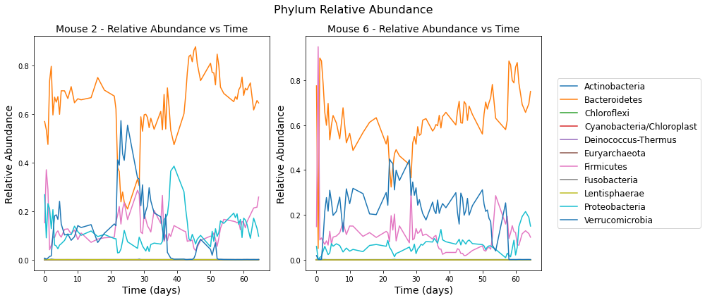

```python
# Create plots of the relative abundance of each phylum
fig, axes = plt.subplots(1, 2, figsize = (14, 6))
ax = axes.flatten()
# Iterate over the classes for mouse 2
for col in mouse2_counts:
    ax[0].plot(mouse2_metadata['time'], mouse2_counts[col], label = col)
ax[0].set_xlabel("Time (days)", fontsize = 14)
ax[0].set_ylabel("Relative Abundance", fontsize = 14)
ax[0].set_title("Mouse 2 - Relative Abundance vs Time", fontsize = 14)
# Iterate over the classes for mouse 2
for col in mouse6_counts:
    ax[1].plot(mouse6_metadata['time'], mouse6_counts[col], label = col)
ax[1].set_xlabel("Time (days)", fontsize = 14)
ax[1].set_ylabel("Relative Abundance", fontsize = 14)
ax[1].set_title("Mouse 6 - Relative Abundance vs Time", fontsize = 14)
ax[1].legend(loc='center left', bbox_to_anchor=(1.05, 0.5), fontsize=12)

fig.suptitle('Phylum Relative Abundance', fontsize=16)
plt.tight_layout();

plt.savefig('plots/phylum_abundance_over_time.png')
```

### 3.3 ASV Gene Groupings

We also sought to understand how we might identify biological groups based on the ASV gene sequences themselves. To explore this, we calculated the edit distance (the minimum number of operations required to transform one string into the other) between each unique amplicon sequence and all of the other sequences, again excluding the taxa identified as having extremely low relative abundances as noted above.

As can be seen in the plots below, which includes both a small sample close-up view and a version with all 886 non-negligible species sequences, many of the taxa have similar genetic profiles, reinforcing the hypothesis that clustering the ASVs taxonomically might help provide an aggregated view of the mice microbiomes.

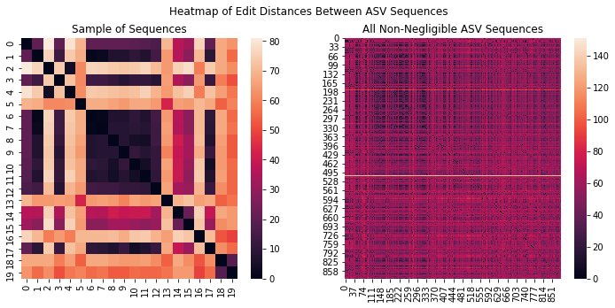

```python
# Create heat map of genetic sequence edit distances

# Add name as col for counts clean
counts_clean_w_names = counts_cleaned.copy()
counts_clean_w_names.index.name = 'name'
counts_clean_w_names.reset_index(inplace=True)

# Join counts_cleaned to asv_and_taxonomy to get grouping options
counts_and_tax = counts_clean_w_names.merge(asv_and_taxonomy, on = 'name')
sequences = counts_and_tax['sequence'].unique()
sequences_subset = sequences[:20]

def create_heatmap(sequences):
    n = len(sequences)
    distance_matrix = np.zeros((n,n))#[[0]*len(sequences)]*len(sequences)

    # N x N Heat Map
    for i in range(len(sequences)):
        for j in range(len(sequences)):
            distance = editdistance.eval(sequences[i], sequences[j])
            distance_matrix[i][j]=distance

    return distance_matrix

distance_mat = create_heatmap(sequences_subset)
distance_mat_full = create_heatmap(sequences)

fig, axes = plt.subplots(1, 2, figsize=(12, 5))
fig.suptitle('Heatmap of Edit Distances Between ASV Sequences')
sns.heatmap(distance_mat, ax=axes[0])
axes[0].set_title('Sample of Sequences')
sns.heatmap(distance_mat_full, ax=axes[1])
axes[1].set_title('All Non-Negligible ASV Sequences')
```

## 4. Modeling

### 4.1 Predicting qPCR Measurements

Given the time-series format of the qPCR measurements, we were interested in using autoregressive models to predict future readings based on lagged qPCR measurements. Specifically, we split the data into measurements that came from mice that received transplants from healthy human donors versus human donors infected with ulcerative colitis (UC) and trained our models on three lagged measurements. We decided to split the data after noticing that models trained on the full data set performed quite poorly, most likely because the nature of qPCR time-series for mice in the two groups are very different.

```python
# Define a function to get the nth previous measurement for a particular qPCR measurement m
def get_prev_measurement(x, n, m):
    subj = int(metadata[metadata['sampleID']==x]['subject'])
    date = int(metadata[metadata['sampleID']==x]['time'])
    samples = metadata[metadata['subject']==subj]
    samples = samples[samples['time']<date].sort_values(by = ['time'], ascending = False)
    n = n-1
    if samples.shape[0]>n:
        s = str(samples.iloc[n]['sampleID'])
    else:
        return "nan"
    if m == 1:
        return float(qpcr[qpcr['sampleID'] == s]['measurement1'])
    elif m == 2:
        return float(qpcr[qpcr['sampleID'] == s]['measurement2'])
    elif m == 3:
        return float(qpcr[qpcr['sampleID'] == s]['measurement3'])
    else:
        raise Exception('measurement m must be in [1,2,3]')

# Define a function to get the full date frame of lagged qPCR measurements
def get_qpcr_full(df=qpcr, timesteps=3):

    # Get the previous three measurements for each measurement of each row in qpcr
    qpcr_bm = df.merge(metadata, left_on='sampleID', right_on='sampleID')
    for m in range(1,4): # Loop through measurements m
        for t in range(1,timesteps+1): # Loop through previous timesteps
            col_name = 'm'+str(m)+'_prev_'+str(t)
            qpcr_bm[col_name] = qpcr_bm.sampleID.apply(lambda x: get_prev_measurement(x,t,m))
        qpcr_bm = qpcr_bm[qpcr_bm[col_name]!= 'nan'] # At this point, col_name will be last timestep

    # Add the donor indicator variable
    qpcr_bm['donor'] = np.where(qpcr_bm.subject.isin([6,7,8,9,10]), 1, 0)

    # Add the perturbation binary variables (note start and end time are the same for all mice)
    qpcr_bm['diet'] = qpcr_bm.time.between(21.5, 28.5).astype(int)
    qpcr_bm['vancomycin'] = qpcr_bm.time.between(35.5, 42.5).astype(int)
    qpcr_bm['gentamicin'] = qpcr_bm.time.between(50.5, 57.5).astype(int)

    # Initialize and fill a new data frame with one measurement on each row
    col_names = ['measurement', 'donor', 'diet', 'vancomycin', 'gentamicin']
    for t in range(1,timesteps+1):
        col_names.append('prev_'+str(t))
    qpcr_full = pd.DataFrame(columns=col_names)
    for i, row in qpcr_bm.iterrows():
        for m in range(1,4):
            measurement_col = 'measurement'+str(m)
            new_row = [np.log(row[measurement_col]), row['donor'], row['diet'], row['vancomycin'], row['gentamicin']]
            for t in range(1,timesteps+1):
                new_row.append(np.log(row['m'+str(m)+'_prev_'+str(t)])) # transform qPCR to log scale
            qpcr_full.loc[3*i+(m-1)] = new_row
    return qpcr_full
```

```python
# Call the function and print out the first few lines
qpcr_full = get_qpcr_full(qpcr, timesteps=3)
qpcr_full.head(10)
```

|  | measurement | donor | diet | vancomycin | gentamicin | prev_1 | prev_2 | prev_3 |
| --- | --- | --- | --- | --- | --- | --- | --- | --- |
| 3 | 25.551351 | 1.0 | 0.0 | 0.0 | 0.0 | 25.883120 | 25.945696 | 26.431573 |
| 4 | 25.718158 | 1.0 | 0.0 | 0.0 | 0.0 | 25.401576 | 26.332394 | 25.465093 |
| 5 | 24.795046 | 1.0 | 0.0 | 0.0 | 0.0 | 25.585563 | 26.149845 | 26.567201 |
| 6 | 25.686418 | 1.0 | 0.0 | 0.0 | 0.0 | 25.551351 | 25.883120 | 25.945696 |
| 7 | 26.096020 | 1.0 | 0.0 | 0.0 | 0.0 | 25.718158 | 25.401576 | 26.332394 |
| 8 | 26.404120 | 1.0 | 0.0 | 0.0 | 0.0 | 24.795046 | 25.585563 | 26.149845 |
| 9 | 25.010251 | 1.0 | 0.0 | 0.0 | 0.0 | 25.686418 | 25.551351 | 25.883120 |
| 10 | 25.996749 | 1.0 | 0.0 | 0.0 | 0.0 | 26.096020 | 25.718158 | 25.401576 |
| 11 | 24.964518 | 1.0 | 0.0 | 0.0 | 0.0 | 26.404120 | 24.795046 | 25.585563 |
| 12 | 25.262775 | 1.0 | 0.0 | 0.0 | 0.0 | 25.010251 | 25.686418 | 25.551351 |

```python
# Split the full data into train and test
X = qpcr_full[['prev_1', 'prev_2', 'prev_3']]
y = qpcr_full['measurement']
X_train, X_test, y_train, y_test = train_test_split(X, y, test_size=0.25, random_state=42)

# Split the data into healthy and UC donor status
qpcr_healthy = qpcr_full[qpcr_full['donor']==0]
qpcr_uc = qpcr_full[qpcr_full['donor']==1]

# Split each of these into train and test
X_healthy = qpcr_healthy[['prev_1', 'prev_2', 'prev_3']]
y_healthy = qpcr_healthy['measurement']
X_healthy_train, X_healthy_test, y_healthy_train, y_healthy_test = train_test_split(X_healthy, y_healthy, test_size=0.25, random_state=42)
X_uc = qpcr_uc[['prev_1', 'prev_2', 'prev_3']]
y_uc = qpcr_uc['measurement']
X_uc_train, X_uc_test, y_uc_train, y_uc_test = train_test_split(X_uc, y_uc, test_size=0.25, random_state=42)
```

#### 4.1.1 Autoregressive Model

First, we train an autoregressive model on the separate healthy and UC donor measurements in order to see whether we can predict future qPCR measurements based on linear combinations of the three previous measurements.

```python
# Train and evaluate an autoregressive model on the healthy donor measurements
healthy_autoreg = LinearRegression()
healthy_autoreg.fit(X_healthy_train, y_healthy_train)
healthy_autoreg_train_pred = healthy_autoreg.predict(X_healthy_train)
healthy_autoreg_test_pred = healthy_autoreg.predict(X_healthy_test)
print('Autoregressive Model Results - Healthy Donor')
print('Train MSE: %.4f'
      % mean_squared_error(y_healthy_train, healthy_autoreg_train_pred))
print('Train R2: %.4f'
      % r2_score(y_healthy_train, healthy_autoreg_train_pred))
print('Test MSE: %.4f'
      % mean_squared_error(y_healthy_test, healthy_autoreg_test_pred))
print('Test R2: %.4f'
      % r2_score(y_healthy_test, healthy_autoreg_test_pred))

# Train and evaluate an autoregressive model on the UC donor measurements
uc_autoreg = LinearRegression()
uc_autoreg.fit(X_uc_train, y_uc_train)
uc_autoreg_train_pred = uc_autoreg.predict(X_uc_train)
uc_autoreg_test_pred = uc_autoreg.predict(X_uc_test)
print('Autoregressive Model Results - UC Donor')
print('Train MSE: %.4f'
      % mean_squared_error(y_uc_train, uc_autoreg_train_pred))
print('Train R2: %.4f'
      % r2_score(y_uc_train, uc_autoreg_train_pred))
print('Test MSE: %.4f'
      % mean_squared_error(y_uc_test, uc_autoreg_test_pred))
print('Test R2: %.4f'
      % r2_score(y_uc_test, uc_autoreg_test_pred))
```

```
Autoregressive Model Results - Healthy Donor
Train MSE: 0.6188
Train R2: 0.3419
Test MSE: 0.5134
Test R2: 0.4228
Autoregressive Model Results - UC Donor
Train MSE: 0.7372
Train R2: 0.2253
Test MSE: 1.2492
Test R2: 0.1479
```

#### 4.1.2 Long-Short Term Memory (LSTM)

Next, we use the same data to train a Long Short-Term Memory (LSTM) network, which is a type of Recurrent Neural Network (RNN) architecture. By introducing concepts of memory and context history, they are particularly well suited for time series data. Before modeling, we first reshape the data into the format required by Keras.

```python
# Reshape original data
X_train = np.array(X_train)
X_train = X_train.reshape((X_train.shape[0], X_train.shape[1], 1))
y_train = np.array(y_train)
X_test = np.array(X_test)
X_test = X_test.reshape((X_test.shape[0], X_test.shape[1], 1))
y_test = np.array(y_test)

# Reshape healthy donor arrays
X_healthy_train = np.array(X_healthy_train)
X_healthy_train = X_healthy_train.reshape((X_healthy_train.shape[0], X_healthy_train.shape[1], 1))
y_healthy_train = np.array(y_healthy_train)
X_healthy_test = np.array(X_healthy_test)
X_healthy_test = X_healthy_test.reshape((X_healthy_test.shape[0], X_healthy_test.shape[1], 1))
y_healthy_test = np.array(y_healthy_test)

# Reshape UC donor arrays
X_uc_train = np.array(X_uc_train)
X_uc_train = X_uc_train.reshape((X_uc_train.shape[0], X_uc_train.shape[1], 1))
y_uc_train = np.array(y_uc_train)
X_uc_test = np.array(X_uc_test)
X_uc_test = X_uc_test.reshape((X_uc_test.shape[0], X_uc_test.shape[1], 1))
y_uc_test = np.array(y_uc_test)
```

```python
# Define a function that creates and compiles a LSTM
def get_lstm(model_name):
    lstm = tf.keras.Sequential(name=model_name)
    lstm.add(Bidirectional(LSTM(64), input_shape=(3,1)))
    lstm.add(Dense(128, activation = "relu"))
    lstm.add(Dense(64, activation = "relu"))
    lstm.add(Dense(1))
    lstm.compile(optimizer=tf.optimizers.Adam(1e-4), loss='mean_squared_error')
    return lstm

# Instantiate an LSTM model for the healthy donor and print summary
lstm_healthy = get_lstm('Healthy')
print(lstm_healthy.summary())
```

```
Model: "Healthy"
_________________________________________________________________
Layer (type)                 Output Shape              Param #
=================================================================
bidirectional (Bidirectional (None, 128)               33792
_________________________________________________________________
dense (Dense)                (None, 128)               16512
_________________________________________________________________
dense_1 (Dense)              (None, 64)                8256
_________________________________________________________________
dense_2 (Dense)              (None, 1)                 65
=================================================================
Total params: 58,625
Trainable params: 58,625
Non-trainable params: 0
_________________________________________________________________
None
```

```python
# Train the model on the healthy donor data
healthy_history = lstm_healthy.fit(X_healthy_train, y_healthy_train, epochs=200, verbose=0)
```

```python
# Predict on train and test
y_healthy_train_pred = lstm_healthy.predict(X_healthy_train)
y_healthy_test_pred = lstm_healthy.predict(X_healthy_test)

# Print out train and test MSE and R2 values
print('LSTM Results - Healthy Donor')
print('Train MSE: %.4f'
      % mean_squared_error(y_healthy_train, y_healthy_train_pred))
print('Train R2: %.4f'
      % r2_score(y_healthy_train, y_healthy_train_pred))
print('Test MSE: %.4f'
      % mean_squared_error(y_healthy_test, y_healthy_test_pred))
print('Test R2: %.4f'
      % r2_score(y_healthy_test, y_healthy_test_pred))
```

```
LSTM Results - Healthy Donor
Train MSE: 0.6263
Train R2: 0.3340
Test MSE: 0.5365
Test R2: 0.3969
```

```python
# Instantiate an LSTM model for the UC donor
lstm_uc = get_lstm('UC')

# Train the model on the UC donor data
uc_history = lstm_uc.fit(X_uc_train, y_uc_train, epochs=200, verbose=0)
```

```python
# Predict on train and test
y_uc_train_pred = lstm_uc.predict(X_uc_train)
y_uc_test_pred = lstm_uc.predict(X_uc_test)

# Print out train and test MSE and R2 values
print('LSTM Results - UC Donor')
print('Train MSE: %.4f'
      % mean_squared_error(y_uc_train, y_uc_train_pred))
print('Train R2: %.4f'
      % r2_score(y_uc_train, y_uc_train_pred))
print('Test MSE: %.4f'
      % mean_squared_error(y_uc_test, y_uc_test_pred))
print('Test R2: %.4f'
      % r2_score(y_uc_test, y_uc_test_pred))
```

```
LSTM Results - UC Donor
Train MSE: 0.7371
Train R2: 0.2255
Test MSE: 1.2485
Test R2: 0.1484
```

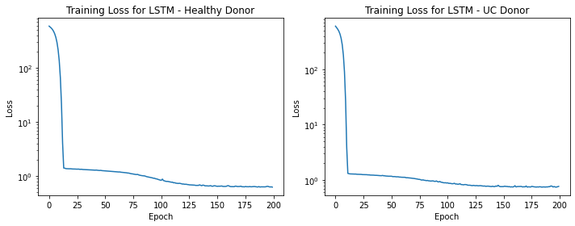

```python
# Plot the training MSE for both LSTMs
fig, ax = plt.subplots(1, 2, figsize=(10,4))
epochs = len(healthy_history.history['loss'])
ax[0].plot(range(epochs), healthy_history.history['loss'], label='Training MSE')
ax[0].set_xlabel('Epoch')
ax[0].set_ylabel('Loss')
ax[0].set_yscale('log')
ax[0].set_title('Training Loss for LSTM - Healthy Donor')
ax[1].plot(range(epochs), uc_history.history['loss'], label='Training MSE')
ax[1].set_xlabel('Epoch')
ax[1].set_ylabel('Loss')
ax[1].set_yscale('log')
ax[1].set_title('Training Loss for LSTM - UC Donor')
plt.tight_layout()
```

### 4.2. Predicting Healthy vs. Ulceritive Colitis Donor

Motivated by our observation that qPCR measurements are easier to predict for mice in the healthy donor group, we decided to pursue a secondary classification task modeling donor health status. In particular, we expect that certain features of the relative abundances of taxa in the mice microbiomes will allow us to distinguish between mice in the healthy donor group versus those in the UC donor group. As described above, the nine mice in the experiment were divided into two cohorts: some received a fecal transplant from a healthy human donor, while others received a transplant from a human donor with UC.

Our next set of models attempt to predict, based on relative abundances of taxa in a microbiome along with perturbations, whether a donor was healthy or had UC. This can be thought of as a sequence classification problem, since we are taking a sequence of data (e.g. the series of measurements for each mouse) and predicting a binary classification (e.g. whether that mouse had a healthy or UC donor).

The first step in building this model is to prepare the data such that we have a time series for each mouse of their non-negligible ASV measurements at that point, plus record of their perturbations and donor status.

```python
# Goal: Format data such that we have full history of each mouse's
# relative abundances along with binary indicator of donor healthy
# and perturbations

# Combine counts with mouse and observation metadata
counts_transposed = counts_cleaned.transpose().reset_index()
all_obs = counts_transposed.merge(metadata, left_on = 'index', right_on = 'sampleID')

# Use SQL-like merge to pull in perturbation timing
sqlcode = '''
select *
from all_obs a
left join perturbations p on a.subject = p.subject and a.time between p.start and p.end
'''
combined = ps.sqldf(sqlcode, locals())

# One hot encode perturbation

# Get one hot encoding of columns B
one_hot = pd.get_dummies(combined.name, prefix = 'perturbation')
# Drop column name as it is now encoded
combined = combined.drop('name',axis = 1)
# Join the encoded df
full_dat = combined.join(one_hot)

# Remove dupe columns
full_dat = full_dat.loc[:,~full_dat.columns.duplicated()]

# Assign donor indicator for mice with healthy vs. UC donor
full_dat['donor'] = np.where(full_dat.subject.isin([6,7,8,9,10]), 1, 0)
```

#### 4.2.1 Vanilla CNN (Non-Sequential)

First, we fit a Vanilla CNN without taking into account the sequential nature of the data. In this scenario, we treat each measurement for each mouse as its own individual observation. This allows for a greater sample size (despite the small number of mice in the experiment) for training and testing.

To ensure we can evaluate model performance based on both a healthy and a UC mouse, we generate a test set consisting of all the measurements from two mice: one healthy, and one with a UC donor (mice 2 and 6), and use the remaining mice for the training set. For this model, our predictors will consist of all of the ASV measurements, along with a binary indicator at each measurement time point denoting whether that perturbation was being applied at that point in time. The outcome variable is a binary indicator denoting whether a mouse had a healthy or UC donor.

Of the 686 total measurements across all 9 mice, 532 are in our training dataset of 7 mice and 154 are in our test set of 2 mice.

```python
# Split into test train:
# Since sample size is small try one healthy/one ill mouse in test
print(f'full_dat shape: {full_dat.shape}')

test_dat = full_dat.loc[full_dat['subject'].isin([2,6])]
train_dat= full_dat.loc[full_dat['subject'].isin([3,4,5,7,8,9,10])]
print(f'train_dat shape: {train_dat.shape}')
print(f'test_dat shape: {test_dat.shape}')

# Split into predictors and targets for training and evaluation
target_train = train_dat['donor']
input_train = train_dat[[c for c in train_dat.columns if 'ASV' in c or 'perturbation' in c]] # only use ASV identifiers

target_test = test_dat['donor']
input_test = test_dat[[c for c in test_dat.columns if 'ASV' in c or 'perturbation' in c]] # only use ASV identifiers

# Create variable indicating number of features
num_features = input_train.shape[1]
```

```
full_dat shape: (686, 896)
train_dat shape: (532, 896)
test_dat shape: (154, 896)
```

```python
# Instantiate model and print summary
donor_model_1 = keras.Sequential(
    [
        Input(shape=(num_features)),
        layers.Dense(200, activation="relu", name="layer1"),
        layers.Dense(10, activation="relu", name="layer2"),
        layers.Dense(1, name="layer3"),
    ]
)
donor_model_1.summary()
```

```
Model: "sequential_1"
_________________________________________________________________
Layer (type)                 Output Shape              Param #
=================================================================
layer1 (Dense)               (None, 200)               178000
_________________________________________________________________
layer2 (Dense)               (None, 10)                2010
_________________________________________________________________
layer3 (Dense)               (None, 1)                 11
=================================================================
Total params: 180,021
Trainable params: 180,021
Non-trainable params: 0
_________________________________________________________________
```

```python
# Compile and train on training mice
donor_model_1.compile(optimizer='sgd', loss='binary_crossentropy', metrics=['accuracy'])
donor_model_1.fit(input_train, target_train, epochs=100)
```

```
<tensorflow.python.keras.callbacks.History at 0x7f3d017b0d50>
```

```python
# Print out model performance
preds_train = donor_model_1.evaluate(input_train, target_train)
print("Train loss, train acc:", preds_train)

preds_test = donor_model_1.evaluate(input_test, target_test)
print("Test loss, test acc:", preds_test)

print("train %s: %.2f%%" % (donor_model_1.metrics_names[1], preds_train[1]*100))
print("test %s: %.2f%%" % (donor_model_1.metrics_names[1], preds_test[1]*100))
```

```
Train loss, train acc: [0.06257487088441849, 0.9849624037742615]
Test loss, test acc: [0.043476205319166183, 0.9805194735527039]
train accuracy: 98.50%
test accuracy: 98.05%
```

As can be seen in the output above, this simple, non-sequential model performs quite well, yielding a high train and test accuracy. This suggests that with a high degree of accuracy, we can predict based on an individual measurement of relative abundances and presence of perturbations, whether a mouse had a healthy donor or one with UC.

As noted earlier in this code report, an important nuance of this dataset is that it is a time series. Each measurement of ASV relative abundances in mice does not exist in isolation, but rather is related to those measurements that came before and after. To account for this data dynamic, we will next explore how this modeling task can be accomplished using an LSTM.

#### 4.2.2 LSTM (Sequential Model) with Bootstrap

LSTMs are suited for time series task because they utilize past observations as part of the training process. Each mouse has a unique history of measurements, so in our next modeling task we will incorporate the entire mouse history into training.

In this model, each mouse will be its own unit of observation (similar to how we would treat sentences in language modeling), with its sequence of ASV measurements comprising its history.

It's worth noting that we have a very small sample size. With only nine mice total (four with healthy donors and five with UC donors), this presents a challenge insofar as our model will not have many mice to train on, and will also have few mice on which to evaluate its performance.

With this limitation in mind, we decided to take a bootstrap approach to assess model training and performance with more variation. With each bootstrap iteration, we randomly select two mice (one from the healthy cohort and one from the UC cohort) to use as our test group, and use the others for the training group. We then train an LSTM using the mice's entire history of relative abundance measurements and perturbation indicators at each timestep, with a goal of predicting its donor status. Then, we evaluate the overall performance across all bootstrapped iterations.

```python
# Shape of data for LSTM should be
# (number of mice x number of observations x number of features)

# Use min observations as number of observations
min_observations = full_dat.groupby('subject').count().min()[0]

healthy_mice = [2,3,4,5]
uc_mice = [6,7,8,9,10]
all_mice = set(healthy_mice+uc_mice)
```

```python
# Define a helper function that creates and compiles a LSTM
def make_lstm():
    model_lstm_boot = keras.Sequential(
        [
        Input(shape=(74, 889)),
        layers.LSTM(50, activation = 'relu'),
        layers.Dense(200, activation="relu", name="layer1"),
        layers.Dense(64, activation="relu", name="layer1.5"),
        layers.Dense(10, activation="relu", name="layer2"),
        layers.Dense(1, name="layer3"),
        ]
    )
    model_lstm_boot.compile(optimizer='adam', loss='binary_crossentropy', metrics=['accuracy'])
    return model_lstm_boot
```

```python
# Check architecture
test_lstm = make_lstm()
test_lstm.summary()
```

```
Model: "sequential_23"
_________________________________________________________________
Layer (type)                 Output Shape              Param #
=================================================================
lstm_23 (LSTM)               (None, 50)                188000
_________________________________________________________________
layer1 (Dense)               (None, 200)               10200
_________________________________________________________________
layer1.5 (Dense)             (None, 64)                12864
_________________________________________________________________
layer2 (Dense)               (None, 10)                650
_________________________________________________________________
layer3 (Dense)               (None, 1)                 11
=================================================================
Total params: 211,725
Trainable params: 211,725
Non-trainable params: 0
_________________________________________________________________
```

```python
# Perform bootstrap
# Takes a while but should run with greater n (maybe 50)

num_boot = 50
train_acc = []
test_acc = []

# In each boot randomly select 1 healthy and one unhealthy mouse for test set
# Use rest for training
for boot in range(num_boot):
    test_mice = []
    for group in [healthy_mice, uc_mice]:
        test_mouse = random.choice(group)
        test_mice.append(test_mouse)
    #print(test_mice)
    test_mice_set = set(test_mice)
    train_mice = [x for x in all_mice if x not in test_mice_set]
    #print(train_mice)

    # Set up train and test data
    test_dat_boot = full_dat.loc[full_dat['subject'].isin(test_mice)]
    train_dat_boot= full_dat.loc[full_dat['subject'].isin(train_mice)]

    x_train_boot = []
    y_train_boot = []
    x_test_boot = []
    y_test_boot = []
    for data in [train_dat_boot, test_dat_boot]:
        for mouse_number in data['subject'].unique():
            mouse_data = data.loc[data['subject'] == mouse_number].sort_values('time')

            # filter out columns
            if data.equals(train_dat_boot):
                y_train_boot.append(mouse_data['donor'].iloc[0])
            else:
                y_test_boot.append(mouse_data['donor'].iloc[0])
            filtered_mouse_data = mouse_data[[c for c in full_dat.columns if 'ASV' in c or 'perturbation' in c]]
            #print(filtered_mouse_data.shape)

            padded_mouse_data = filtered_mouse_data[:min_observations] #padded_mouse_data[0:min_observations]
            #print(padded_mouse_data.shape)
            if data.equals(train_dat_boot):
                x_train_boot.append(padded_mouse_data)
            else:
                x_test_boot.append(padded_mouse_data)
    x_train_boot_np = np.array(x_train_boot)
    y_train_boot_np = np.array(y_train_boot)

    x_test_boot_np = np.array(x_test_boot)
    y_test_boot_np = np.array(y_test_boot)

    #make_and_fit_lstm(x_train_boot_np, y_train_boot_np)
    model_lstm_boot = make_lstm()
    model_lstm_boot.fit(x_train_boot_np, y_train_boot_np, epochs=100, verbose = False)

    preds_train_lstm_boot = model_lstm_boot.evaluate(x_train_boot_np, y_train_boot_np)
    print("Train loss, train acc:", preds_train_lstm_boot)

    preds_test_lstm_boot = model_lstm_boot.evaluate(x_test_boot_np, y_test_boot_np)
    print("Test loss, test acc:", preds_test_lstm_boot)

    train_acc.append(preds_train_lstm_boot[1])
    test_acc.append(preds_test_lstm_boot[1])
```

[output not shown]

[output cut: 95 more lines]

[output not shown]

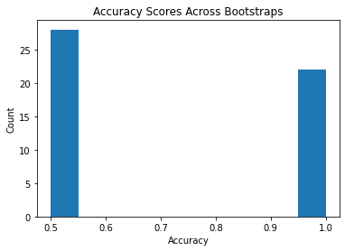

```python
# Quick histogram
# Since there are only two mice in test group, it
# Can either get 0, 50% or 100% accuracy.
plt.hist(test_acc)  # bins=30
plt.ylabel('Count')
plt.xlabel('Accuracy')
plt.title('Accuracy Scores Across Bootstraps')
```

```python
# Print out average performance
print(f'Avg. Train Accuracy Across Bootstraps: {round(np.mean(train_acc),4)}')
print(f'Avg. Test Accuracy Across Bootstraps: {round(np.mean(test_acc),4)}')
```

```
Avg. Train Accuracy Across Bootstraps: 0.68
Avg. Test Accuracy Across Bootstraps: 0.72
```

As can be seen by the output above, the LSTM model trained on each mouse's entire history does not perform as well as the previous vanilla non-sequential model, with a lower average test accuracy score across bootstraps. However, the average test accuracy across bootstraps is better than what we would expect via random choice (50%), suggesting that the model is able to learn and predict to some level of reliability despite the tiny sample size. This is also visible from the histogram of bootstrapped test accuracy scores. Because there are only two mice in each bootstrapped test group, the accuracy scores can be either 0%, 50%, or 100%. There are nearly as many 100% bootstrapped test accuracy scores as 50%, which indicates positive test performance in many of the bootstrapped iterations.

It would be interesting to try this sequential method in scenarios with many more mice to evaluate its relative performance to the non-sequential model.

#### 4.2.3 Multivariate LSTM (Sequential Model) using Phylum Relative Abundance

Similar to the previous LSTM model, each mouse represents a sample which means that we are dealing with a very small total sample size of 9 with a held out test set of 2 mice: 1 with a healthy donor, and 1 with a UC donor.

The multivariate LSTM model is trained on time-series data with each time point containing multiple features. These features correspond to the relative abundance of every phylum. By aggregating the data by phylum, we hope to realize general patterns in the time-series data that are indicitive of donor status (microbiome derived from a patient with UC or a healthy donor.)

```python
# Group the counts dataframe by class and compute the relative abundance per phylum
phylum_abundance = counts.assign(Class = asv_and_taxonomy['Phylum'].to_numpy()).groupby('Class').sum()
phylum_abundance = phylum_abundance.transpose()

# Normalize every row by the row sum to create relative abundance values
rowsums = phylum_abundance.sum(axis=1)
phylum_abundance = phylum_abundance.div(rowsums, axis='index')

# Specify the mouse ID for samples in the metadata
donor_data = metadata.copy()
donor_data['mouseID'] = [x.split('-')[0] for x in donor_data['sampleID']]
# Group the data by mouse ID and order the data in chronological order
donor_data = donor_data.sort_values(['mouseID', 'time'], axis=0, ascending=True)

# Sort the phylum abundance data based on the sample ID order found in the donor data
sorted_indices = [np.where(phylum_abundance.index == element)[0][0] for element in donor_data['sampleID']]
phylum_abundance = phylum_abundance.iloc[sorted_indices,:]
```

```python
# Define the response (the donor status)
donor_data['donor_status'] = np.where(donor_data['subject'].isin([6, 7, 8, 9, 10]), 1, 0)

# Specify the training and test sets (the test set consists of one healthy mouse
train = phylum_abundance.loc[donor_data['mouseID'].astype(int).isin([3,4,5,7,8,9,10]).to_numpy(),:].to_numpy()
test = phylum_abundance.loc[donor_data['mouseID'].astype(int).isin([2,6]).to_numpy(),:].to_numpy()
donor_train = donor_data.loc[donor_data['mouseID'].astype(int).isin([3,4,5,7,8,9,10]).to_numpy(),:]
donor_test = donor_data.loc[donor_data['mouseID'].astype(int).isin([2,6]).to_numpy(),:]

print(f"The shape of X train and X test are {train.shape} and {test.shape} respectively.")
```

```
The shape of X train and X test are (532, 11) and (154, 11) respectively.
```

```python
# Define the predictors and response for the training set
X_train,y_train = [],[]
for mouse in donor_train['mouseID'].unique():
    # Pull the data associated with the given mouse
    training_data = train[donor_train['mouseID'] == mouse,:]
    training_response = donor_train.loc[donor_train['mouseID'] == mouse,:]['donor_status'].unique()[0]

    X_train.append(training_data)
    y_train.append(training_response)

# Define the predictors and response for the test set
X_test,y_test = [],[]
for mouse in donor_test['mouseID'].unique():
    # Pull the data associated with the given mouse
    test_data = test[donor_test['mouseID'] == mouse,:]
    test_response = donor_test.loc[donor_test['mouseID'] == mouse,:]['donor_status'].unique()[0]

    X_test.append(test_data)
    y_test.append(test_response)
```

```python
# Pad the the training and test set given that the mice contributed varying numbers of samples

# Determine the max number of samples contributed
max_samples = np.max([x.shape[0] for x in X_train])

# Pad the training set
for i in range(len(X_train)):
    data = X_train[i]
    # Define the padding
    padding = np.zeros((max_samples-data.shape[0], data.shape[1]))
    # Add the padding
    data = np.append(data, padding, axis=0)
    X_train[i] = data.copy()

# Pad the test set
for i in range(len(X_test)):
    data = X_test[i]
    # Define the padding
    padding = np.zeros((max_samples-data.shape[0], data.shape[1]))
    # Add the padding
    data = np.append(data, padding, axis=0)
    X_test[i] = data.copy()

X_train = np.array(X_train)
X_test = np.array(X_test)
y_train = np.array(y_train)
y_test = np.array(y_test)
```

```python
# Define a function used to create the LSTM model
def create_LSTM(input_size, hidden_states):
    model = Sequential()
    model.add(Input(shape=input_size))
    model.add(LSTM(hidden_states, activation = 'relu'))
    model.add(Dense(256, activation='relu'))
    model.add(Dense(128, activation='relu'))
    model.add(Dense(64, activation='relu'))
    model.add(Dense(32, activation='relu'))
    model.add(Dense(1, activation='sigmoid'))

    return model
```

```python
# Define the model
model = create_LSTM(X_train[0].shape, 64)

# Compile the model
model.compile(optimizer='adam', loss='binary_crossentropy', metrics=['accuracy'])
# Train the model
history = model.fit(X_train, y_train, epochs=100)
```

```python
train_accuracy = model.evaluate(X_train, y_train)[1]
print(f"The training set accuracy is {train_accuracy:0.4f}")

test_accuracy = model.evaluate(X_test, y_test)[1]
print(f"The training set accuracy is {test_accuracy:0.4f}")
```

```
WARNING:tensorflow:6 out of the last 11 calls to <function Model.make_test_function.<locals>.test_function at 0x7f3ceda4c7a0> triggered tf.function retracing. Tracing is expensive and the excessive number of tracings could be due to (1) creating @tf.function repeatedly in a loop, (2) passing tensors…
The training set accuracy is 0.5714
The training set accuracy is 0.5000
```

## 5. Results

### 5.2 Limitations

- Given the small sample size of nine mice, we did not have enough data to determine whether our LSTM classification models were truly unable to accurately distinguish between mice in the two groups based on ASV relative abundance histories.

### 5.3 Future Work

- We could try predicting qPCR measurements using more lagged timesteps.
- Perhaps reservoir computing would allow us to forecast qPCR measurements based on longer histories, especially given more data.
- Now that we know that knowledge of ASV relative abundance and perturbations are predictive of mouse donor group, we could explore more deeply how relative abundancies change in response to particular perturbations for mice in the two groups.

[figure not shown]

Created in Deepnote